# Predicción de Pérdida Actuarial usando XGBoost

Eduardo Arias

2025-02-11

# 1. Introducción

## 1.1 Contexto y Relevancia

La predicción precisa de pérdidas actuariales es fundamental en la industria de seguros. Las compañías de seguros necesitan estimar con precisión las pérdidas futuras para:

- Establecer reservas adecuadas
- Fijar primas competitivas
- Gestionar eficientemente el riesgo
- Cumplir con requisitos regulatorios

Este trabajo aborda el problema de predecir el costo final de reclamaciones de compensación laboral utilizando técnicas avanzadas de Machine Learning.

## 1.2 Objetivos

1. Desarrollar un modelo predictivo robusto para estimar costos finales de reclamaciones
2. Identificar los factores más influyentes en el costo final de las reclamaciones
3. Proporcionar insights accionables para la gestión de riesgos

# 2. Datos y Metodología

## 2.1 Preparación del Entorno

```r
# Cargar librerías necesarias
library(tidyverse)      # Para manipulación de datos
library(tidymodels)     # Para modelado predictivo
library(tidytext)       # Para procesamiento de texto
library(dplyr)          # Para manipulación de datos
library(SnowballC)      # Para stemming
library(stopwords)      # Para stop words
library(scales)         # Para formateo de números
library(wordcloud)      # Para visualización
library(tm)             # Para procesamiento de texto adicional
library(skimr)          # Para EDA
library(lubridate)      # Para manejo de fechas
library(parallel)       # Para paralelización
library(doParallel)     # Para paralelización
library(vip)            # Para importancia de variables
library(moments)        # Para cálculos estadísticos (skewness, kurtosis)
library(GGally)         # Para visualizaciones
library(corrplot)       # Para visualizaciones
library(knitr)          # Para tablas bonitas
```

## 2.2 Carga y Exploración Inicial de Datos

```r
# Cargar datos
datos_completos <- read_csv('Data/actuarial_loss/train.csv')

datos_completos <- datos_completos %>% select(-ClaimNumber)

# Exploración inicial
glimpse(datos_completos)
```

```
## Rows: 54,000
## Columns: 14
## $ DateTimeOfAccident        <dttm> 2002-04-09 07:00:00, 1999-01-07 11:00:00, 1…
## $ DateReported              <dttm> 2002-07-05, 1999-01-20, 1996-04-14, 2005-07…
## $ Age                       <dbl> 48, 43, 30, 41, 36, 50, 39, 56, 49, 30, 20, …
## $ Gender                    <chr> "M", "F", "M", "M", "M", "M", "M", "M", "M",…
## $ MaritalStatus             <chr> "M", "M", "U", "S", "M", "M", "M", "M", "M",…
## $ DependentChildren         <dbl> 0, 0, 0, 0, 0, 0, 0, 0, 0, 0, 0, 0, 0, 0, 0,…
## $ DependentsOther           <dbl> 0, 0, 0, 0, 0, 0, 0, 0, 0, 0, 0, 0, 0, 0, 0,…
## $ WeeklyWages               <dbl> 500.00, 509.34, 709.10, 555.46, 377.10, 200.…
## $ PartTimeFullTime          <chr> "F", "F", "F", "F", "F", "F", "F", "F", "F",…
## $ HoursWorkedPerWeek        <dbl> 38.0, 37.5, 38.0, 38.0, 38.0, 38.0, 38.0, 40…
## $ DaysWorkedPerWeek         <dbl> 5, 5, 5, 5, 5, 5, 5, 5, 5, 5, 5, 5, 5, 5, 5,…
## $ ClaimDescription          <chr> "LIFTING TYRE INJURY TO RIGHT ARM AND WRIST …
## $ InitialIncurredCalimsCost <dbl> 1500, 5500, 1700, 15000, 2800, 500, 500, 500…
## $ UltimateIncurredClaimCost <dbl> 4748.2034, 6326.2858, 2293.9491, 17786.4872,…
```

## 2.3 Análisis Exploratorio de Datos

### 2.3.1 Estadísticas Descriptivas

```r
# Resumen estadístico completo
skim(datos_completos)
```

Data summary

| Name | datos_completos |
| --- | --- |
| Number of rows | 54000 |
| Number of columns | 14 |
| _______________________ |  |
| Column type frequency: |  |
| character | 4 |
| numeric | 8 |
| POSIXct | 2 |
| ________________________ |  |
| Group variables | None |

**Variable type: character**

| skim_variable | n_missing | complete_rate | min | max | empty | n_unique | whitespace |
| --- | --- | --- | --- | --- | --- | --- | --- |
| Gender | 0 | 1 | 1 | 1 | 0 | 3 | 0 |
| MaritalStatus | 29 | 1 | 1 | 1 | 0 | 3 | 0 |
| PartTimeFullTime | 0 | 1 | 1 | 1 | 0 | 2 | 0 |
| ClaimDescription | 0 | 1 | 3 | 94 | 0 | 28114 | 0 |

**Variable type: numeric**

| skim_variable | n_missing | complete_rate | mean | sd | p0 | p25 | p50 | p75 | p100 | hist |
| --- | --- | --- | --- | --- | --- | --- | --- | --- | --- | --- |
| Age | 0 | 1 | 33.84 | 12.12 | 13.00 | 23.00 | 32.00 | 43.00 | 81 | ▇▇▅▂▁ |
| DependentChildren | 0 | 1 | 0.12 | 0.52 | 0.00 | 0.00 | 0.00 | 0.00 | 9 | ▇▁▁▁▁ |
| DependentsOther | 0 | 1 | 0.01 | 0.11 | 0.00 | 0.00 | 0.00 | 0.00 | 5 | ▇▁▁▁▁ |
| WeeklyWages | 0 | 1 | 416.36 | 248.64 | 1.00 | 200.00 | 392.20 | 500.00 | 7497 | ▇▁▁▁▁ |
| HoursWorkedPerWeek | 0 | 1 | 37.74 | 12.57 | 0.00 | 38.00 | 38.00 | 40.00 | 640 | ▇▁▁▁▁ |
| DaysWorkedPerWeek | 0 | 1 | 4.91 | 0.55 | 1.00 | 5.00 | 5.00 | 5.00 | 7 | ▁▁▁▇▁ |
| InitialIncurredCalimsCost | 0 | 1 | 7841.15 | 20584.08 | 1.00 | 700.00 | 2000.00 | 9500.00 | 2000000 | ▇▁▁▁▁ |
| UltimateIncurredClaimCost | 0 | 1 | 11003.37 | 33390.99 | 121.89 | 926.34 | 3371.24 | 8197.25 | 4027136 | ▇▁▁▁▁ |

**Variable type: POSIXct**

| skim_variable | n_missing | complete_rate | min | max | median | n_unique |
| --- | --- | --- | --- | --- | --- | --- |
| DateTimeOfAccident | 0 | 1 | 1988-01-01 09:00:00 | 2005-12-31 10:00:00 | 1997-01-07 10:00:00 | 36673 |
| DateReported | 0 | 1 | 1988-01-08 00:00:00 | 2006-09-23 00:00:00 | 1997-02-16 00:00:00 | 6653 |

```r
# Análisis de valores faltantes
missing_analysis <- colSums(is.na(datos_completos))/nrow(datos_completos)*100
print("Porcentaje de valores faltantes por columna:")
```

```
## [1] "Porcentaje de valores faltantes por columna:"
```

```r
print(missing_analysis[missing_analysis > 0])
```

```
## MaritalStatus
##     0.0537037
```

```r
# Realizar el análisis agrupado por MaritalStatus
analisis_marital <- datos_completos %>%
  group_by(MaritalStatus) %>%
  summarise(
    mean = mean(UltimateIncurredClaimCost, na.rm = TRUE),
    median = median(UltimateIncurredClaimCost, na.rm = TRUE),
    count = n()
  )

# Mostrar los resultados
print(analisis_marital)
```

```
## # A tibble: 4 × 4
##   MaritalStatus   mean median count
##   <chr>          <dbl>  <dbl> <int>
## 1 M             12025.  4166. 22516
## 2 S              9106.  2323. 26161
## 3 U             16068.  5852.  5294
## 4 <NA>           5326.  1482.    29
```

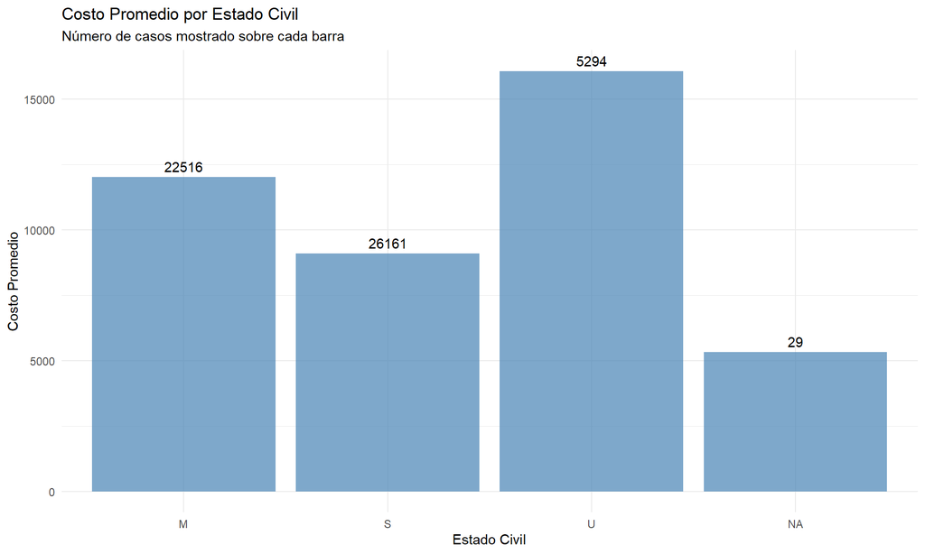

```r
# Visualización
ggplot(analisis_marital, aes(x = MaritalStatus, y = mean)) +
  geom_col(fill = "steelblue", alpha = 0.7) +
  geom_text(aes(label = count), vjust = -0.5) +
  labs(
    title = "Costo Promedio por Estado Civil",
    subtitle = "Número de casos mostrado sobre cada barra",
    x = "Estado Civil",
    y = "Costo Promedio"
  ) +
  theme_minimal()
```

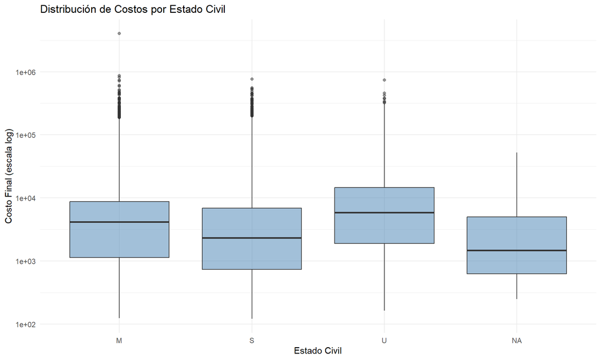

```r
# Visualización adicional con boxplot para ver la distribución
ggplot(datos_completos, aes(x = MaritalStatus, y = UltimateIncurredClaimCost)) +
  geom_boxplot(fill = "steelblue", alpha = 0.5) +
  scale_y_log10() + # Usando escala logarítmica para mejor visualización
  labs(
    title = "Distribución de Costos por Estado Civil",
    x = "Estado Civil",
    y = "Costo Final (escala log)"
  ) +
  theme_minimal()
```

```r
# Imputación inicial
datos_completos <- datos_completos %>%
  mutate(
    Days_To_Report = as.numeric(difftime(DateReported, DateTimeOfAccident, units="days"))
  )

# Calculamos el modo de MaritalStatus
mode_marital <- datos_completos %>%
  filter(!is.na(MaritalStatus)) %>%
  count(MaritalStatus) %>%
  arrange(desc(n)) %>%
  dplyr::slice(1) %>%
  pull(MaritalStatus)

# Calculamos las medias por grupo
medias_por_grupo <- datos_completos %>%
  group_by(MaritalStatus) %>%
  summarise(media_claim = mean(UltimateIncurredClaimCost, na.rm = TRUE))

# Aplicamos las imputaciones
datos_completos <- datos_completos %>%
  # Primero imputamos MaritalStatus
  mutate(
    MaritalStatus = if_else(is.na(MaritalStatus), mode_marital, MaritalStatus)
  ) %>%
  # Luego hacemos el join con las medias por grupo
  left_join(medias_por_grupo, by = "MaritalStatus") %>%
  # Finalmente aplicamos la imputación de UltimateIncurredClaimCost
  mutate(
    UltimateIncurredClaimCost = if_else(
      is.na(UltimateIncurredClaimCost),
      media_claim,
      UltimateIncurredClaimCost
    )
  ) %>%
  # Eliminamos la columna auxiliar
  select(-media_claim)
```

### 2.3.2 Análisis de la Variable Objetivo

```r
# Estadísticas de la variable objetivo
summary_stats <- datos_completos %>%
  summarise(
    n = n(),
    mean = mean(UltimateIncurredClaimCost),
    median = median(UltimateIncurredClaimCost),
    sd = sd(UltimateIncurredClaimCost),
    IQR = IQR(UltimateIncurredClaimCost),
    skewness = skewness(UltimateIncurredClaimCost),
    kurtosis = kurtosis(UltimateIncurredClaimCost),
    min = min(UltimateIncurredClaimCost),
    max = max(UltimateIncurredClaimCost),
    q25 = quantile(UltimateIncurredClaimCost, 0.25),
    q75 = quantile(UltimateIncurredClaimCost, 0.75),
    q95 = quantile(UltimateIncurredClaimCost, 0.95),
    q99 = quantile(UltimateIncurredClaimCost, 0.99)
  )

print("Estadísticas de la variable objetivo:")
```

```
## [1] "Estadísticas de la variable objetivo:"
```

```r
print(summary_stats)
```

```
## # A tibble: 1 × 13
##       n   mean median     sd   IQR skewness kurtosis   min      max   q25   q75
##   <int>  <dbl>  <dbl>  <dbl> <dbl>    <dbl>    <dbl> <dbl>    <dbl> <dbl> <dbl>
## 1 54000 11003.  3371. 33391. 7271.     37.6    3943.  122. 4027136.  926. 8197.
## # ℹ 2 more variables: q95 <dbl>, q99 <dbl>
```

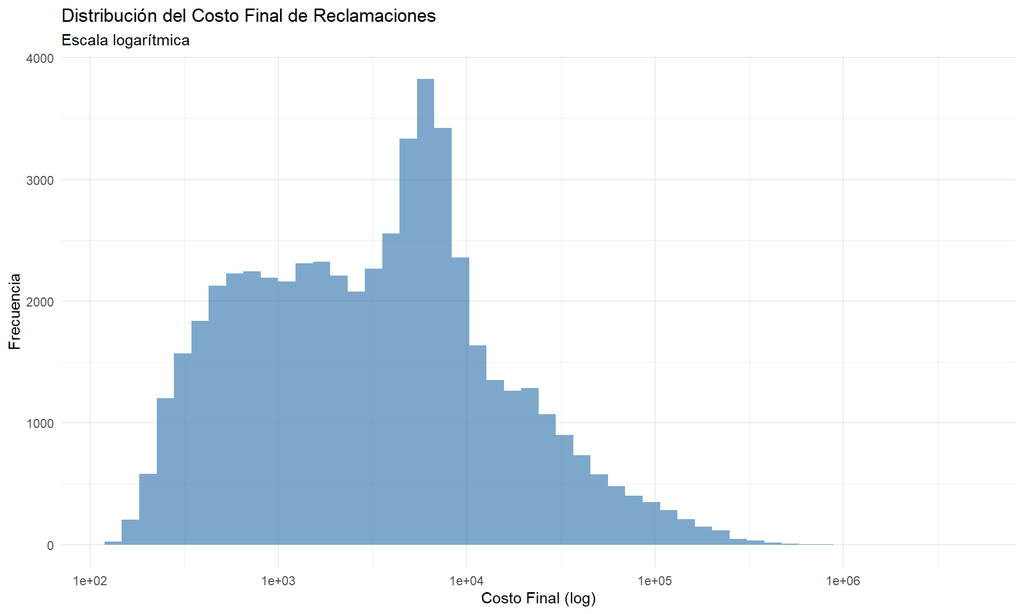

```r
# Visualización más completa
p1 <- ggplot(datos_completos, aes(x = UltimateIncurredClaimCost)) +
  geom_histogram(bins = 50, fill = "steelblue", alpha = 0.7) +
  scale_x_log10() +
  labs(title = "Distribución del Costo Final de Reclamaciones",
       subtitle = "Escala logarítmica",
       x = "Costo Final (log)",
       y = "Frecuencia") +
  theme_minimal()

p2 <- ggplot(datos_completos, aes(sample = UltimateIncurredClaimCost)) +
  stat_qq() +
  stat_qq_line(color = "red") +
  scale_y_log10() +
  labs(title = "Q-Q Plot del Costo Final de Reclamaciones",
       subtitle = "Escala logarítmica",
       x = "Cuantiles teóricos",
       y = "Cuantiles muestrales") +
  theme_minimal()

# Mostrar gráficos
print(p1)
```

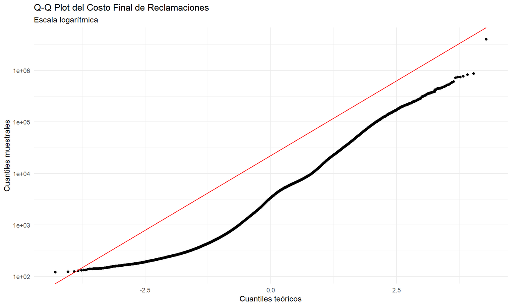

```r
print(p2)
```

```r
# Proporción de valores extremos
extremes_analysis <- datos_completos %>%
  summarise(
    prop_above_mean = mean(UltimateIncurredClaimCost > mean(UltimateIncurredClaimCost)),
    prop_above_2sd = mean(UltimateIncurredClaimCost > mean(UltimateIncurredClaimCost) +
                           2*sd(UltimateIncurredClaimCost)),
    prop_above_3sd = mean(UltimateIncurredClaimCost > mean(UltimateIncurredClaimCost) +
                           3*sd(UltimateIncurredClaimCost))
  )

print("Análisis de valores extremos:")
```

```
## [1] "Análisis de valores extremos:"
```

```r
print(extremes_analysis)
```

```
## # A tibble: 1 × 3
##   prop_above_mean prop_above_2sd prop_above_3sd
##             <dbl>          <dbl>          <dbl>
## 1           0.192         0.0260         0.0152
```

### 2.3.3 Análisis Temporal

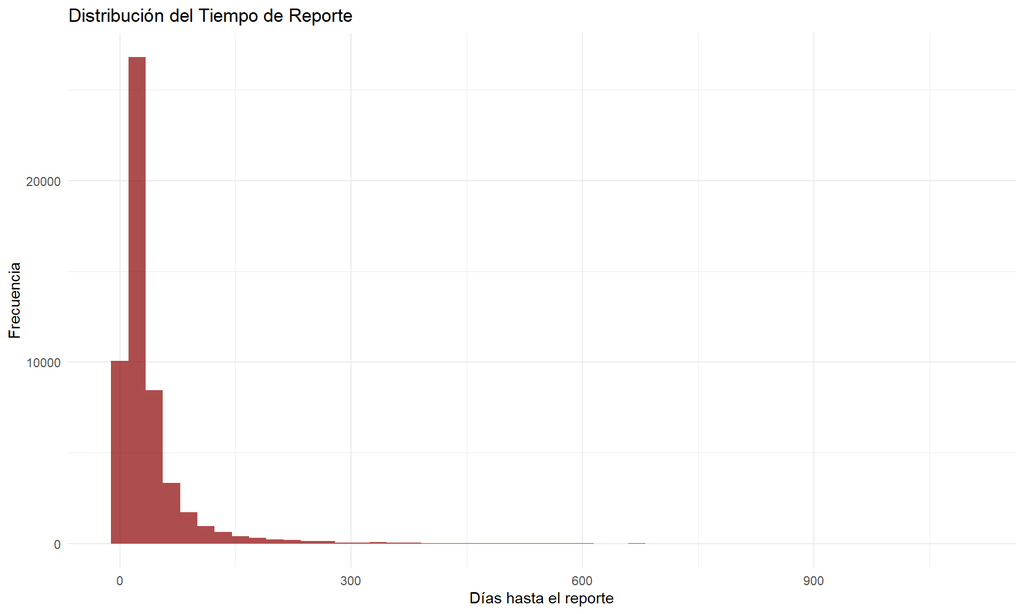

```r
# Procesar fechas
datos_completos  <- datos_completos  %>%
  mutate(
    Days_To_Report = as.numeric(difftime(DateReported, DateTimeOfAccident, units="days"))
  )

# Análisis de tiempo de reporte
ggplot(datos_completos , aes(x = Days_To_Report)) +
  geom_histogram(bins = 50, fill = "darkred", alpha = 0.7) +
  labs(title = "Distribución del Tiempo de Reporte",
       x = "Días hasta el reporte",
       y = "Frecuencia") +
  theme_minimal()
```

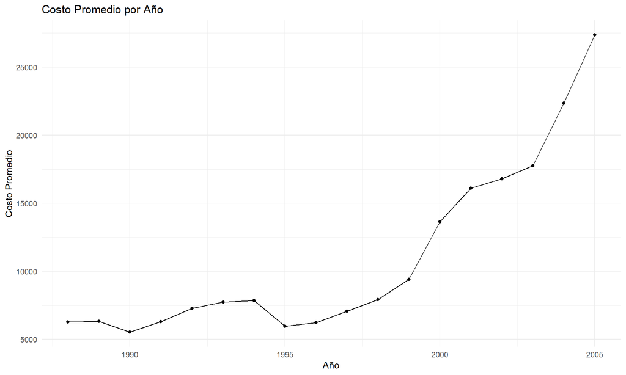

```r
# Costo promedio por año
datos_completos  %>%
  mutate(Year = year(DateTimeOfAccident)) %>%
  group_by(Year) %>%
  summarise(
    avg_cost = mean(UltimateIncurredClaimCost),
    n_claims = n()
  ) %>%
  ggplot(aes(x = Year, y = avg_cost)) +
  geom_line() +
  geom_point() +
  labs(title = "Costo Promedio por Año",
       x = "Año",
       y = "Costo Promedio") +
  theme_minimal()
```

### 2.3.4 Análisis de Texto de Reclamaciones

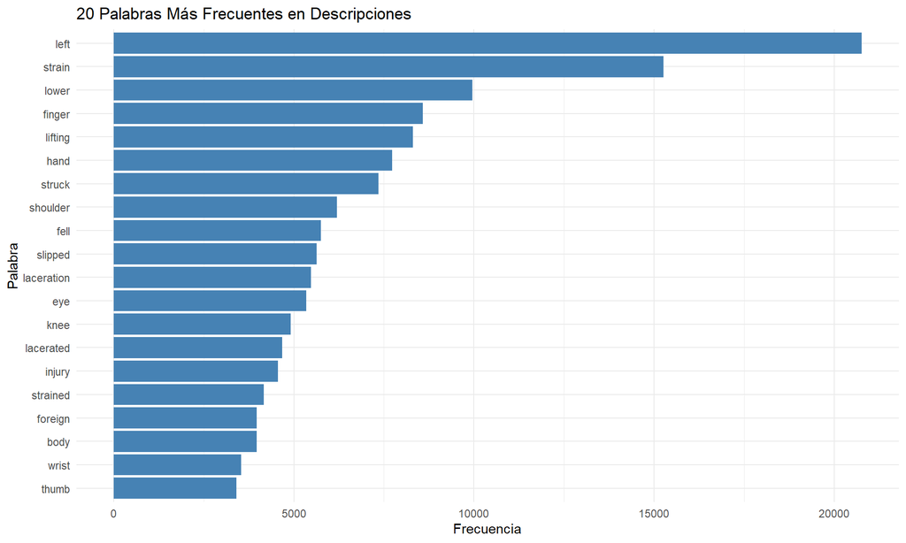

```r
# Procesamiento inicial de texto
claim_tokens <- datos_completos  %>%
  unnest_tokens(word, ClaimDescription) %>%
  anti_join(stop_words) %>%
  count(word, sort = TRUE)

# Top 20 palabras más frecuentes
claim_tokens %>%
  head(20) %>%
  ggplot(aes(x = reorder(word, n), y = n)) +
  geom_col(fill = "steelblue") +
  coord_flip() +
  labs(title = "20 Palabras Más Frecuentes en Descripciones",
       x = "Palabra",
       y = "Frecuencia") +
  theme_minimal()
```